None

# Проект: Защита персональных данных клиентов.

# Содержание

### Задание на проект

Вам нужно защитить данные клиентов страховой компании «Хоть потоп». Разработайте такой метод преобразования данных, чтобы по ним было сложно восстановить персональную информацию. Обоснуйте корректность его работы.

Нужно защитить данные, чтобы при преобразовании качество моделей машинного обучения не ухудшилось. Подбирать наилучшую модель не требуется.

### Описание данных

Набор данных находится в файле insurance.csv.

- Признаки: пол, возраст и зарплата застрахованного, количество членов его семьи.
- Целевой признак: количество страховых выплат клиенту за последние 5 лет.

### План работы

1.Загружаем и изучаем данные.

2.Отвечаем на вопрос и обосновываем свое решение.

Признаки умножаем на обратимую матрицу. Проверяем, изменится ли качество линейной регрессии? (В любом случае, её можно обучить заново.)

a) Изменится. Приводим примеры матриц.

b) Не изменится. Указываем, как связаны параметры линейной регрессии в исходной задаче и в преобразованной.

3.Предлагаем алгоритм преобразования данных для решения задачи. Обосновываем, почему качество линейной регрессии не поменяется.

4.Программируем этот алгоритм, применив матричные операции. Проверяем, что качество линейной регрессии из sklearn не отличается до и после преобразования. Применяем метрику R2.

## 1. Загрузка данных.

```python
# Все import соберем в начале проекта:
import warnings
warnings.filterwarnings('ignore')

import pandas as pd
import numpy as np
import seaborn as sns

import matplotlib.pyplot as plt
from sklearn.model_selection import train_test_split
from sklearn.linear_model import LinearRegression
from sklearn.metrics import r2_score, mean_squared_error


# Не ограничиваем максимальное количество отображающихся столбцов
pd.set_option('display.max_columns', None)

# Настроим, чтобы числа в датасетах отражались с 3 знаками после запятой;
pd.set_option('display.float_format', '{:.3f}'.format)

RANDOM_FIX_NUMBER = 12345  # Введем глобальную переменную для значения random_state
```

### 1.1. Загрузка локального и удаленного файла с данными:

Изучили файл с предоставленными данными insurance.csv и применяем символ запятая для разделения данных:

```python
dataset_remote_path = 'https://code.s3.yandex.net/datasets/insurance.csv'

dataset_local_path = 'datasets/insurance.csv'

try:
    data = pd.read_csv(dataset_local_path, sep=',')
    print('Local datasets is loaded successfully.')
except:
    data = pd.read_csv(dataset_remote_path, sep=',')
    print('Remote datasets is loaded successfully.')
```

```
Local datasets is loaded successfully.
```

### 1.2. Изучим датасет.

#### 1.2.1. Размер данных в изучаемом файле:

```python
# Найдем размер датасета.
data.shape, data.size
```

```
((5000, 5), 25000)
```

Набор данных довольно большой: 5 000 строк х 5 столбцов.

#### 1.2.2. Информация, содержащаяся в столбцах:

```python
data.head()
```

|  | Пол | Возраст | Зарплата | Члены семьи | Страховые выплаты |
| --- | --- | --- | --- | --- | --- |
| 0 | 1 | 41.000 | 49600.000 | 1 | 0 |
| 1 | 0 | 46.000 | 38000.000 | 1 | 1 |
| 2 | 0 | 29.000 | 21000.000 | 0 | 0 |
| 3 | 0 | 21.000 | 41700.000 | 2 | 0 |
| 4 | 1 | 28.000 | 26100.000 | 0 | 0 |

В нашем dataset всего 5 столбцов со следующей информацией:

**Признаки**

- Пол.
- Возраст.
- Зарплата застрахованного.
- Члены семьи — количество членов его семьи.

**Целевой признак**

- Страховые выплаты — количество страховых выплат клиенту за последние 5 лет.

#### 1.2.3. Проверка корректности названия столбцов.

Удовлетворительно. Названия столбцов изменять не будем.

#### 1.2.4. Поиск дубликатов

```python
data.duplicated().sum()
```

```
153
```

Видим, что дубликатов не много. Только 153 их общего массива в 5000. И их можно смело удалить. Тем не менее, сначала посмотрим их подробнее.

```python
duplicated_data = data[data.duplicated()]
display(duplicated_data)
```

|  | Пол | Возраст | Зарплата | Члены семьи | Страховые выплаты |
| --- | --- | --- | --- | --- | --- |
| 281 | 1 | 39.000 | 48100.000 | 1 | 0 |
| 488 | 1 | 24.000 | 32900.000 | 1 | 0 |
| 513 | 0 | 31.000 | 37400.000 | 2 | 0 |
| 718 | 1 | 22.000 | 32600.000 | 1 | 0 |
| 785 | 0 | 20.000 | 35800.000 | 0 | 0 |
| ... | ... | ... | ... | ... | ... |
| 4793 | 1 | 24.000 | 37800.000 | 0 | 0 |
| 4902 | 1 | 35.000 | 38700.000 | 1 | 0 |
| 4935 | 1 | 19.000 | 32700.000 | 0 | 0 |
| 4945 | 1 | 21.000 | 45800.000 | 0 | 0 |
| 4965 | 0 | 22.000 | 40100.000 | 1 | 0 |

153 rows × 5 columns

Вообще говоря, они могут и не оказаться дубликатами. Большинство признаков - категориальные. Да и значение заработной платы округлено до сотых.

Тем не менее, так как объяснений дублированию у нас нет, удалим повторяющиеся объекты. Особенно в связи с их малочисленностью.

```python
# Удалим явные дубликаты.
data = data.drop_duplicates()
data.shape
```

```
(4847, 5)
```

#### 1.2.5. Пропущенные данные.

```python
data.isna().sum()
```

```
Пол                  0
Возраст              0
Зарплата             0
Члены семьи          0
Страховые выплаты    0
dtype: int64
```

Пропущенных данных нет.

#### 1.2.6. Изучим наши данные на мультиколлинеарность признаков.

Посмотрим взаимную корреляцию признаков датасета:

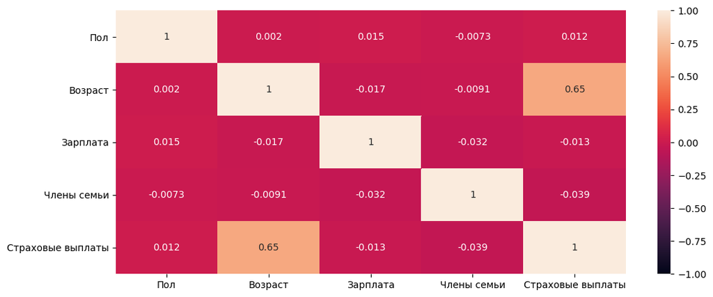

```python
plt.figure(figsize = (12,5))
_ = sns.heatmap(data.corr(), vmax=1, vmin=-1, annot=True)
```

Отмечаем сильную зависимость между возрастом и страховыми выплатами. Больше зависимостей между признаками нет.

#### 1.2.7. Визуальная оценка нормальности распределений.

Построим общую диаграмму для всех признаков:

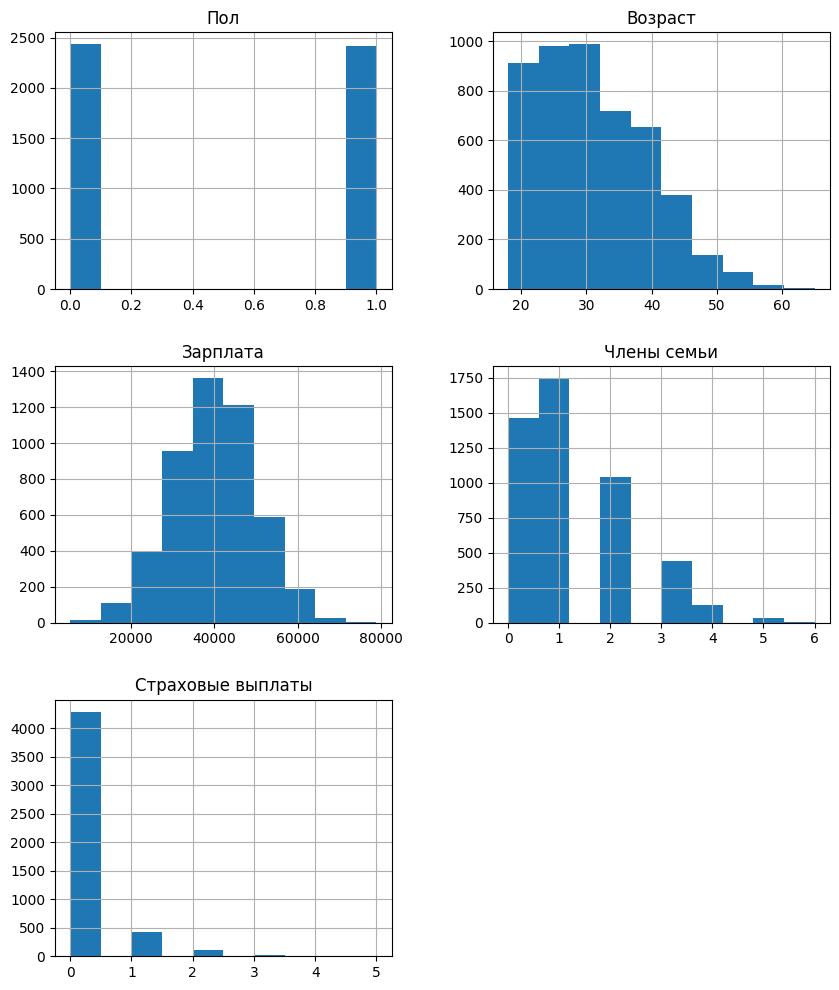

```python
data.hist(figsize=(10, 12));
```

#### 1.2.8. Изучим каждый признак:

```python
# Изучим значение признака 'gender':
data['Пол'].value_counts()
```

```
0    2431
1    2416
Name: Пол, dtype: int64
```

Клиенты распределены по половому признаку одинаково.

```python
# Изучим значение признака 'Возраст':
data['Возраст'].describe()
```

```
count   4847.000
mean      31.024
std        8.488
min       18.000
25%       24.000
50%       30.000
75%       37.000
max       65.000
Name: Возраст, dtype: float64
```

- Клиенты распределены по возрасту в диапазоне от 18 до 65 лет.
- Аномальных значений нет. Среднее значение (31 год) очень близко значению медианы (30 лет).

```python
# Изучим значение признака 'Зарплата':
data['Зарплата'].describe()
```

```
count    4847.000
mean    39895.812
std      9972.954
min      5300.000
25%     33200.000
50%     40200.000
75%     46600.000
max     79000.000
Name: Зарплата, dtype: float64
```

Видим, что:

1. Значение зарплат Клиентов находится в диапазоне от 5 300 до 79 000 руб
2. Аномальных значений нет, и среднее значение (39 895 руб) очень близко медианному значению (40 200 руб).
3. Отмечаем симметричное нормальное распределение данных по зарплатам Клиентов.

```python
# Изучим значение признака 'Члены семьи':
data['Члены семьи'].value_counts()
```

```
1    1748
0    1461
2    1038
3     437
4     124
5      32
6       7
Name: Члены семьи, dtype: int64
```

Клиенты или имеют детей в количестве от 1 до 6, или бездетные.

```python
# Изучим значение признака 'Страховые выплаты':
data['Страховые выплаты'].value_counts()
```

```
0    4284
1     423
2     114
3      18
4       7
5       1
Name: Страховые выплаты, dtype: int64
```

Большинство Клиентов не имели страховых выплат или получали их в количестве от 1 до 5.

### 1.3. Подготовим датасеты.

```python
# Выделим целевой признак:
features = data.drop('Страховые выплаты', axis=1)
target = data['Страховые выплаты']

# Разделим данные на обучающую и тестовую выборки в соотношении 80:20:
features_train, features_test, target_train, target_test = train_test_split(
    features, target, test_size=0.2, random_state=RANDOM_FIX_NUMBER)
```

### 1.4. Промежуточные выводы.

1.Загрузка данных провелена успешно.

2.Набор данных довольно большой: 5 000 строк х 5 столбцов.

3.Названия столбцов не требуют корректировки.

4.Явные дубликаты удалены.

5.Пропущенных данных нет.

6.Отмечена сильная зависимость между возрастом и страховыми выплатами. Это вполне разумно.

7.Аномальных значений не обнаружено.

## 2. Умножение матриц.

**Инструкция:**

В этом задании вы можете записывать формулы в *Jupyter Notebook.*

Чтобы записать формулу внутри текста, окружите её символами доллара \$; если снаружи — двойными символами \$\$. Эти формулы записываются на языке вёрстки *LaTeX.*

Для примера мы записали формулы линейной регрессии. Можете их скопировать и отредактировать, чтобы решить задачу.

Работать в *LaTeX* необязательно.

Предсказания:

$$ a = Xw $$

Задача обучения:

$$ w = \arg\min_w MSE(Xw, y) $$

Формула обучения:

$$ w[X] = (X^T X)^{-1} X^T y $$

Обозначения:

- $X$ — матрица признаков (нулевой столбец состоит из единиц)
- $y$ — вектор целевого признака
- $P$ — матрица, на которую умножаются признаки
- $w$ — вектор весов линейной регрессии (нулевой элемент равен сдвигу)

**Задание:**

Отвечаем на вопрос и обосновываем свое решение.

Признаки умножаем на обратимую матрицу. Проверяем, изменится ли качество линейной регрессии? (В любом случае, её можно обучить заново.)

a) Изменится. Приводим примеры матриц.

b) Не изменится. Указываем, как связаны параметры линейной регрессии в исходной задаче и в преобразованной.

**Вопрос:**

Признаки умножают на обратимую матрицу. Изменится ли качество линейной регрессии?.

**Ответ:**

Не изменится.

**Обоснование:**

Что означает, что качество линейной регрессии не изменится при умножении признаков на обратимую матрицу? Это означает, что предсказание останется прежним.

Докажем это.

**Первый способ**. Предсказание рассчитывается, как : $a = X w$

Формула обучения весов модели: $$ w = (X^T X)^{-1} X^T y $$

Домножим матрицу признаков X на некоторую обратимую матрицу $P$ (т.е., обладающую свойством $PP^{-1}=E$, где $E$ - единичная матрица):

$$ w_P = ((XP)^T XP)^{-1} (XP)^T y $$

Применим формулу $(AB)^T=B^T A^T$ и получим:

$$ w_P = (P^TX^T XP)^{-1} P^TX^T y $$

Применим формулу $(ABС)^{-1} = С^{-1}B^{-1}A^{-1}$:

$$ w_P = P^{-1} (X^T X)^{-1} (P^T)^{-1} P^T X^T y $$

Отмечаем, что $(P^T)^{-1} P^T = E$, поэтому формула упроститься:

$$ w_P = P^{-1} (X^T X)^{-1} X^T y $$

Используем формулу обучения весов модели $w = (X^T X)^{-1} X^T y$:

$$ w_P = P^{-1} w $$

**Тогда, по формуле предсказаний $a=Xw$:**

$$a_p=X_p w_p$$

Применим $X_p = X P$ и $w_P = P^{-1} w$:

$$a_p=X P P^{-1} w = X w = a$$

В итоге, мы получили, что $a = a_p$!

**Второй способ**, доказательство через $w_P = \arg\min_w MSE(XPw_p, y)$

Применим ранее нами полученное: $w_P = P^{-1} w$:

$$ w_P = \arg\min_w MSE(X P P^{-1} w, y) $$

Далее, уже известное: $(P^T)^{-1} P^T = E$, и формула упроститься:

$$ w_P = \arg\min_w MSE(X w, y) $$

**В соответствии с заданием, выполняем задачу:**

*b) Не изменится. Указываем, как связаны параметры линейной регрессии в исходной задаче и в преобразованной.*

Создадим сокращенную запись массива на основе обучающей выборки с добавлением столбца, состоящего из единиц и находящегося в нулевой позиции:

```python
X = np.concatenate((np.ones((features_train.shape[0], 1)),
                    features_train), axis=1) #построчно
y = target_train

# Используем формулу обучения:
w = np.linalg.inv(X.T @ X) @ X.T @ y

print("Коэффициенты линейной регрессии:\n", w)

print("Коэффициенты линейной регрессии без величины сдвига w0:\n", w[1:])
```

```
Коэффициенты линейной регрессии:
 [-9.74238661e-01  1.52535832e-02  3.64619543e-02  1.79690961e-07
 -1.41285669e-02]
Коэффициенты линейной регрессии без величины сдвига w0:
 [ 1.52535832e-02  3.64619543e-02  1.79690961e-07 -1.41285669e-02]
```

```python
# Найдем коэффициенты линейной регрессии
# по модели LinearRegression() из библиотеки sklearn

lin_reg = LinearRegression()
lin_reg.fit(features_train, target_train)

print("Коэффициенты линейной регрессии:\n", lin_reg.coef_)
```

```
Коэффициенты линейной регрессии:
 [ 1.52535832e-02  3.64619543e-02  1.79690961e-07 -1.41285669e-02]
```

```python
# Настроим, чтобы числа в датасетах отражались с 3 знаками после запятой;
pd.set_option('display.float_format', '{:.10f}'.format)

table = pd.DataFrame({'Сокращенная запись' : w[1:],
                      'LinearRegression' : lin_reg.coef_,
                      'Разница' : w[1:] - lin_reg.coef_,
                     }, index=['k1:', 'k2:', 'k3:', 'k4:'])
print(table)
```

```
     Сокращенная запись  LinearRegression       Разница
k1:        0.0152535832      0.0152535832 -0.0000000000
k2:        0.0364619543      0.0364619543  0.0000000000
k3:        0.0000001797      0.0000001797 -0.0000000000
k4:       -0.0141285669     -0.0141285669 -0.0000000000
```

## 3. Алгоритм преобразования.

**Задание:**

Предложите алгоритм преобразования данных для решения задачи. Обоснуйте, почему качество линейной регрессии не поменяется.

**Алгоритм:**

Используем полученный в предыдущем разделе опыт с информацией о том, что умножение признаков на любую обратимую матрицу с размерностью с высотой, равной количеству признаков, не меняет качество линейной регрессии и не меняет значение предсказания.

1. Создаем случайную *обратимую* квадратную матрицу $P$ с размером, равным количеству признаков в исходном датасете.
2. Умножаем признаки обучающей и тестовой выборок на матрицу $P$.
3. Создаем класс с функциями обучения и предсказания.
4. Обучаем модель и предсказываем целевой признак.
5. Считаем R2 и сравниваем метрики R2 модели для исходной и преобразованной матриц.

**Обоснование:**

Создаем гипотезу о равенстве предсказаний для исходной $a$ и преобразованной $a'$ матриц: $$a = a'$$ $$Xw = X'w'$$

Выше было установлено, что:

*При умножении матрицы признаков на обратимую матрицу, вектор целевого признака не меняется и, следовательно, качество линейной регрессии не меняется.*:

$$X(X^T X)^{-1} X^T y = (XP) ((XP)^T (XP))^{-1} (XP)^T y$$

## 4. Проверка алгоритма.

**Задание**

Запрограммируйте свой алгоритм преобразования, применив матричные операции. Проверьте, что качество линейной регрессии из sklearn не отличается до и после преобразования. Примените метрику R2.

### 4.1. Создание случайной *обратимой* матрицы $P$

Посредством матрицы $P$ реализуем метод преобразования данных так, чтобы по ним было сложно восстановить персональную информацию Клиентов страховой компании.

#### 4.1.1 Делаем случайную квадратную матрицу $P$ с размером, равным количеству признаков в обучающей выборке.

```python
P = np.random.normal(size=(features_train.shape[1], features_train.shape[1]))

print("Матрица P:")
display(P.round(5))

# Для нахождения обратимой матрицы воспользуемся функцией numpy.linalg.inv(),
# создав обратную матрицу.
# Для проверки обратимости матрицы $P$, перемножим $P$ с обратной матрицей:

print('\nПроверка на единичную матрицу:')
display((P @ np.linalg.inv(P)).round(5))
```

```
Матрица P:
```

```
array([[ 0.08743,  0.04624,  0.9573 ,  0.8173 ],
       [-0.39496, -0.94892, -0.01471,  1.28718],
       [-0.84312,  0.76594,  1.03716,  0.34643],
       [-0.15846, -1.09216,  0.21284, -0.4798 ]])
```

```
Проверка на единичную матрицу:
```

```
array([[ 1.,  0., -0., -0.],
       [-0.,  1.,  0., -0.],
       [-0., -0.,  1., -0.],
       [-0., -0., -0.,  1.]])
```

#### 4.1.2 Функция гарантированного создания обратимой матрицы.

```python
# Функция создания матрицы до тех пор, пока не получим обратимую

def get_rand_matrix():
    det = 0
    while det == 0:
        # data.shape[1]-1 - исключаем w0
        matrix = np.random.normal(size=(data.shape[1]-1,
                                        data.shape[1]-1))
        det = np.linalg.det(matrix)
    return matrix

P = get_rand_matrix()
print('Матрица P:\n', P)

print('\nПроверка на единичную матрицу:')
display((P @ np.linalg.inv(P)).round(5))
```

```
Матрица P:
 [[-0.0476565   0.38592294  2.03155568  2.43710111]
 [ 1.48856863 -0.59596807 -1.007563   -0.65886428]
 [-1.18586121  0.9522244   0.1807659  -0.22034316]
 [ 0.59843142  1.68985033  0.08245736  0.42975857]]

Проверка на единичную матрицу:
```

```
array([[ 1., -0.,  0., -0.],
       [ 0.,  1.,  0., -0.],
       [-0.,  0.,  1.,  0.],
       [ 0.,  0.,  0.,  1.]])
```

#### 4.1.3 Функция гарантированного создания обратимой матрицы через рекурсию.

```python
def func(dim):
    transform_matrix = np.random.rand(dim, dim)
    try:
        inv = np.linalg.inv(transform_matrix)
        return transform_matrix, inv
    except:
        func(dim)

_, P = func(data.shape[1] - 1) # data.shape[1]-1 - исключаем w0
print('Матрица P:\n', P)

print('\nПроверка на единичную матрицу:')
display((P @ np.linalg.inv(P)).round(5))
```

```
Матрица P:
 [[-0.03305284 -1.06476878 -4.31550892  5.06874814]
 [ 0.79694824  0.18350321  7.89998354 -6.52108079]
 [-1.49048261  1.19260229 -3.53601865  3.17442186]
 [ 0.91709794  0.77583659 -0.67973994 -1.18911998]]

Проверка на единичную матрицу:
```

```
array([[ 1.,  0., -0.,  0.],
       [ 0.,  1.,  0., -0.],
       [-0.,  0.,  1., -0.],
       [ 0.,  0.,  0.,  1.]])
```

Получили единичную матрицу. **Созданная матрица $P$ является обратимой.**

### 4.2. Умножаем признаки обучающей и тестовой выборок на матрицу 𝑃.

```python
# Настроим, чтобы числа в датасетах отражались с 3 знаками после запятой;
pd.set_option('display.float_format', '{:.3f}'.format)

features_train_P = features_train @ P
features_test_P = features_test @ P

display(features_train_P.head())
display(features_test_P.head())
```

|  | 0 | 1 | 2 | 3 |
| --- | --- | --- | --- | --- |
| 640 | -44095.971 | 35306.166 | -104444.952 | 93780.297 |
| 4510 | -85084.919 | 68103.137 | -201701.945 | 181088.751 |
| 1623 | -62121.957 | 49738.199 | -147156.773 | 132129.470 |
| 3460 | -50657.195 | 40552.409 | -120047.930 | 107784.238 |
| 1820 | -52278.243 | 41870.150 | -123760.115 | 111126.380 |

|  | 0 | 1 | 2 | 3 |
| --- | --- | --- | --- | --- |
| 1335 | -70332.482 | 56293.984 | -166722.696 | 149687.796 |
| 3875 | -98197.334 | 78597.298 | -232775.145 | 208990.795 |
| 166 | -50499.260 | 40435.760 | -119616.008 | 107400.396 |
| 3003 | -28733.399 | 23025.932 | -67938.420 | 61009.641 |
| 424 | -40949.778 | 32806.556 | -96878.473 | 86994.253 |

Посмотрим, изменились ли данные после преобразования исходной матрицы:

```python
# исходный датасет
display(features_train.head())
```

|  | Пол | Возраст | Зарплата | Члены семьи |
| --- | --- | --- | --- | --- |
| 640 | 0 | 28.000 | 29600.000 | 0 |
| 4510 | 0 | 26.000 | 57100.000 | 1 |
| 1623 | 1 | 38.000 | 41700.000 | 1 |
| 3460 | 1 | 23.000 | 34000.000 | 1 |
| 1820 | 0 | 45.000 | 35100.000 | 2 |

```python
# преобразованная матрица
display((features_train_P @ np.linalg.inv(P)).head())
```

|  | 0 | 1 | 2 | 3 |
| --- | --- | --- | --- | --- |
| 640 | -0.000 | 28.000 | 29600.000 | 0.000 |
| 4510 | -0.000 | 26.000 | 57100.000 | 1.000 |
| 1623 | 1.000 | 38.000 | 41700.000 | 1.000 |
| 3460 | 1.000 | 23.000 | 34000.000 | 1.000 |
| 1820 | -0.000 | 45.000 | 35100.000 | 2.000 |

### 4.3. Создание класса c функциями обучения и предсказания.

```python
class LinearRegressionMyClass:
    """Создаём cобственный класс модели линейной регрессии."""
    def fit(self, features_train, target_train):
        """Функция:
           - примает обучающие признаки и целевой признак,
           - в матрицу Х добляет столбец, состоящий
           только из единиц (он идет нулевым),
           - создает атрибуты w и w0.
        """
        X = np.concatenate((np.ones((features_train.shape[0], 1)), features_train), axis=1)
        y = target_train
        w = np.linalg.inv(X.T @ X) @ X.T @ y
        self.w = w[1:]
        self.w0 = w[0]

    def predict(self, features_test):
        """Возвращаем вектор весов (w) + сдвиг предсказания."""
        return features_test.dot(self.w) + self.w0
```

### 4.4. Функция для обучения модели, предсказания целевого признака и расчёта метрик.

Напишем функцию model_my() для предсказания метрик, применив созданный ранее класс модели линейной регрессии LinearRegressionMyClass.

```python
dataset_final = pd.DataFrame(columns=['model', 'matrix', 'R2 / MSE', 'score'])


def model_my(x_train, x_test, y_train, y_test,
             model_name = 'LinearRegression',
             matrix = 'NoMatrix',
             metric = 'NoMetric'):

    if model_name == 'LinearRegression':
        model = LinearRegression()
        print('Классическая модель линейной регрессии.')
    elif model_name == 'LinearRegressionMyClass':
        model = LinearRegressionMyClass()
        print('Модель линейной регрессии LinearRegressionMyClass.')
    else:
        print('Не указана модель для работы.')
        return

    model.fit(x_train, y_train)
    predictions = model.predict(x_test)

    if metric == 'R2':
        score = r2_score(y_test, predictions)
        print('R2 модели:', score)
        print(f'R2 модели (округлённо): {score:.7f}')
    elif metric == 'MSE':
        score = mean_squared_error(y_test, predictions)
        print('MSE модели:', score)
        print(f'MSE модели (округлённо): {score:.8f}')
    else:
        score = 0
        print('Не указана рассчитываемая метрика.')

    dataset_final.loc[len(dataset_final.index )] = \
    [model_name, matrix, metric, score]
```

### 4.5. Сравнение метрик классической и нашей моделей линейной регрессии для исходной и преобразованной матриц.

```python
# R2 для классической модели и исходной выборки:
for name_model in ['LinearRegression', 'LinearRegressionMyClass']:
    print('\nИсходная выборка.')
    model_my(features_train, features_test,
             target_train, target_test,
             name_model, 'Исходная выборка', 'R2')

    print('\nПреобразованная (зашифрованная) матрица.')
    model_my(features_train_P, features_test_P,
             target_train, target_test,
             name_model, 'Преобразованная матрица', 'R2')
```

```
Исходная выборка.
Классическая модель линейной регрессии.
R2 модели: 0.4160549216151198
R2 модели (округлённо): 0.4160549

Преобразованная (зашифрованная) матрица.
Классическая модель линейной регрессии.
R2 модели: 0.416054921615699
R2 модели (округлённо): 0.4160549

Исходная выборка.
Модель линейной регрессии LinearRegressionMyClass.
R2 модели: 0.4160549216151216
R2 модели (округлённо): 0.4160549

Преобразованная (зашифрованная) матрица.
Модель линейной регрессии LinearRegressionMyClass.
R2 модели: 0.4160549315673402
R2 модели (округлённо): 0.4160549
```

Значение метрики R2 для исходной и преобразованной матриц, а также для обоих моделей линейной регрессии одинаковы с точностью до 7 знаков после запятой.

```python
# MSE для классической модели и исходной выборки:
for name_model in ['LinearRegression', 'LinearRegressionMyClass']:
    print('\nИсходная выборка.')
    model_my(features_train, features_test,
             target_train, target_test,
             name_model, 'Исходная выборка', 'MSE')

    print('\nПреобразованная (зашифрованная) матрица.')
    model_my(features_train_P, features_test_P,
             target_train, target_test,
             name_model, 'Преобразованная матрица', 'MSE')
```

```
Исходная выборка.
Классическая модель линейной регрессии.
MSE модели: 0.1231125531449998
MSE модели (округлённо): 0.12311255

Преобразованная (зашифрованная) матрица.
Классическая модель линейной регрессии.
MSE модели: 0.12311255314487769
MSE модели (округлённо): 0.12311255

Исходная выборка.
Модель линейной регрессии LinearRegressionMyClass.
MSE модели: 0.12311255314499943
MSE модели (округлённо): 0.12311255

Преобразованная (зашифрованная) матрица.
Модель линейной регрессии LinearRegressionMyClass.
MSE модели: 0.12311255104678319
MSE модели (округлённо): 0.12311255
```

Значение метрики MSE для исходной и преобразованной матриц, а также для обоих моделей линейной регрессии одинаковы с точностью до 8 знаков после запятой.

```python
pd.set_option('display.float_format', '{:.7f}'.format)
dataset_final
```

|  | model | matrix | R2 / MSE | score |
| --- | --- | --- | --- | --- |
| 0 | LinearRegression | Исходная выборка | R2 | 0.4160549 |
| 1 | LinearRegression | Преобразованная матрица | R2 | 0.4160549 |
| 2 | LinearRegressionMyClass | Исходная выборка | R2 | 0.4160549 |
| 3 | LinearRegressionMyClass | Преобразованная матрица | R2 | 0.4160549 |
| 4 | LinearRegression | Исходная выборка | MSE | 0.1231126 |
| 5 | LinearRegression | Преобразованная матрица | MSE | 0.1231126 |
| 6 | LinearRegressionMyClass | Исходная выборка | MSE | 0.1231126 |
| 7 | LinearRegressionMyClass | Преобразованная матрица | MSE | 0.1231126 |

**Промежуточный вывод:**

Качество линейной регрессии из sklearn *LinearRegression* и собственной модели линейной регрессии *LinearRegressionMyClass* не отличается до и после преобразования.

## 6. Общий вывод.

**По результатам исследования можно отметить следующие факты и сделать следующие выводы:**

1.От страховой компании получен файл, содержащий 5000 объектов со следующими признаками:

Признаки:

- Пол.
- Возраст.
- Зарплата застрахованного.
- Количество членов семьи застрахованного.

Целевой признак:

- Страховые выплаты — количество страховых выплат клиенту за последние 5 лет.

2.Данные подготовлены для дальнейшего анализа.

3.На вопрос: "*Признаки умножают на обратимую матрицу. Изменится ли качество линейной регрессии?*" дан ответ "*Не изменится.*". Приведено обоснование такого ответа.

5.Предложен алгоритм преобразования данных для решения задачи шифрования персональной информации Клиентов страховой компании. Приведено его обоснование.

6.Создана случайная обратимая матрица $𝑃$. Проверена ее обратимость.

8.Создан собственный класс *LinearRegressionMyClass* c функциями обучения и предсказания.

9.Установлено, что качество линейной регрессии из sklearn *LinearRegression* и собственной модели линейной регрессии *LinearRegressionMyClass* не отличается до и после преобразования. Проверка проведена с использованием метрик *R2* и *MSE*.

Вернутся к общему списку проектов курса “Data Science” Яндекс-практикума